# Preproceso de datos - TFM

Carles Figuera (cfiguerap)

# Preproceso de datos

El objectivo es preparar el fichero para su posterior análisis.

## 1. Fichero de consumos

1. **Cargamos el fichero y se hace una breve descripción del contenido.**

```r
data = read.csv("./initial_dataset/block_0.csv", stringsAsFactors = FALSE)
for (i in 1:9) {
  next_block = read.csv(paste(c("./initial_dataset/block_", i, ".csv"), collapse=''), stringsAsFactors = FALSE)
  data <- rbind(data, next_block)
}
summary(data)
```

```
##     LCLid               tstp           energy.kWh.hh.
##  Length:14515689    Length:14515689    Length:14515689
##  Class :character   Class :character   Class :character
##  Mode  :character   Mode  :character   Mode  :character
```

- Hay 14515689 registros.
- Hay 3 variables.
- Las variables son: LCLid, tstp, energy.kWh.hh..
2. **Renombramos columnas para facilitar el trabajo**

```r
names(data)[names(data) == "LCLid"] <- "id"
names(data)[names(data) == "tstp"] <- "fecha"
names(data)[names(data) == "energy.kWh.hh."] <- "consumo"
```

3. **Nos quedaremos con la media de todas las lecturas agrupando por su fecha.**

```r
data$id <- NULL
data$consumo <- suppressWarnings(as.double(data$consumo))
data <- data[!is.na(data$consumo),]  # omitir NA
data <- aggregate(data["consumo"], by=list(data$fecha), mean)
headTail(data)
```

|  | Group.1 | consumo |
| --- | --- | --- |
| 1 | 2011-11-28 12:30:00.0000000 | 0.3 |
| 2 | 2011-11-28 13:00:00.0000000 | 0.21 |
| 3 | 2011-11-28 13:30:00.0000000 | 0.16 |
| 4 | 2011-11-28 14:00:00.0000000 | 0.14 |
| ... | NA | ... |
| 39477 | 2014-02-27 22:30:00.0000000 | 0.43 |
| 39478 | 2014-02-27 23:00:00.0000000 | 0.38 |
| 39479 | 2014-02-27 23:30:00.0000000 | 0.33 |
| 39480 | 2014-02-28 00:00:00.0000000 | 0.26 |

4. **Verificar el tipo de variable.**

```r
sapply(data, class)
```

```
##     Group.1     consumo
## "character"   "numeric"
```

Podemos ver que los datos de fecha deberían ser Date.

```r
names(data)[names(data) == "Group.1"] <- "fecha"
data$fecha <- as.POSIXlt(data$fecha, format = '%Y-%m-%d %H:%M:%S.0000000')
headTail(data)
```

|  | fecha | consumo |
| --- | --- | --- |
| 1 |  | 0.3 |
| 2 |  | 0.21 |
| 3 |  | 0.16 |
| 4 |  | 0.14 |
| ... |  | ... |
| 39477 |  | 0.43 |
| 39478 |  | 0.38 |
| 39479 |  | 0.33 |
| 39480 |  | 0.26 |

5. **Comprobamos que no tenemos valores perdidos en los datos**

```r
colSums(is.na(data))
```

```
##   fecha consumo
##       4       0
```

Existen valores nulos, así que haremos lo siguiente:

- Las fechas, pondremos el valor anterior sumando 30 minutos
- Los consumos, omitiremos el valor

```r
idx <- which(is.na(data$fecha))
for (i in which(is.na(data$fecha))) {
  newDate <- as.POSIXlt(data$fecha[i-1])
  newDate$min <- newDate$min + 30
  data$fecha[i] <- as.POSIXlt(newDate)
}

data <- data[!is.na(data$consumo),]  # omitir NA
```

## 2. Fichero de festivos

6. **Crearemos una nueva columna para marcar los días festivos con los datos de vacaciones**

```r
festivos = read.csv("./initial_dataset/uk_bank_holidays.csv", stringsAsFactors = FALSE)
headTail(festivos)
```

|  | Bank.holidays | Type |
| --- | --- | --- |
| 1 | 2012-12-26 | Boxing Day |
| 2 | 2012-12-25 | Christmas Day |
| 3 | 2012-08-27 | Summer bank holiday |
| 4 | 2012-05-06 | Queen?s Diamond Jubilee (extra bank holiday) |
| ... | NA | NA |
| 22 | 2014-05-05 | Early May bank holiday |
| 23 | 2014-04-21 | Easter Monday |
| 24 | 2014-04-18 | Good Friday |
| 25 | 2014-01-01 | New Year?s Day |

7. **Igual que con el anterior fichero, pasamos la fecha de vacaciones de character a Date**

```r
names(festivos)[names(festivos) == "Bank.holidays"] <- "dia"
festivos$dia <- as.POSIXlt(festivos$dia, format = '%Y-%m-%d')
headTail(festivos)
```

|  | dia | Type |
| --- | --- | --- |
| 1 |  | Boxing Day |
| 2 |  | Christmas Day |
| 3 |  | Summer bank holiday |
| 4 |  | Queen?s Diamond Jubilee (extra bank holiday) |
| ... |  | NA |
| 22 |  | Early May bank holiday |
| 23 |  | Easter Monday |
| 24 |  | Good Friday |
| 25 |  | New Year?s Day |

8. **Creamos una nueva columna en el dataframe anterior (data) donde se indique que el día es festivo. Indicaremos (con un 1) días festivos y no laborables. También miraremos los días laborables**

```r
data$festivo <- 0
festivos$value <- 1

data$festivo <- ifelse(!is.na(match(format(data$fecha, format="%y-%m-%d"), format(festivos$dia, format="%y-%m-%d"))), 1, 0)
data$festivo <- ifelse(data$festivo == 0 & isWeekday(data$fecha), 0, 1)

headTail(data)
```

|  | fecha | consumo | festivo |
| --- | --- | --- | --- |
| 1 |  | 0.3 | 0 |
| 2 |  | 0.21 | 0 |
| 3 |  | 0.16 | 0 |
| 4 |  | 0.14 | 0 |
| ... |  | ... | ... |
| 39477 |  | 0.43 | 0 |
| 39478 |  | 0.38 | 0 |
| 39479 |  | 0.33 | 0 |
| 39480 |  | 0.26 | 0 |

## 3. Fichero meteorológico

9. **Ya tenemos indicadas en las fechas los días festivos y laborables. Ahora vamos a hacer lo mismo para los datos meteorológicos**

```r
meteo = read.csv("./initial_dataset/weather_hourly_darksky.csv", stringsAsFactors = FALSE)
headTail(meteo)
```

|  | visibility | windBearing | temperature | time | dewPoint | pressure | apparentTemperature | windSpeed | precipType | icon | humidity | summary |
| --- | --- | --- | --- | --- | --- | --- | --- | --- | --- | --- | --- | --- |
| 1 | 5.97 | 104 | 10.24 | 2011-11-11 00:00:00 | 8.86 | 1016.76 | 10.24 | 2.77 | rain | partly-cloudy-night | 0.91 | Partly Cloudy |
| 2 | 4.88 | 99 | 9.76 | 2011-11-11 01:00:00 | 8.83 | 1016.63 | 8.24 | 2.95 | rain | partly-cloudy-night | 0.94 | Partly Cloudy |
| 3 | 3.7 | 98 | 9.46 | 2011-11-11 02:00:00 | 8.79 | 1016.36 | 7.76 | 3.17 | rain | partly-cloudy-night | 0.96 | Partly Cloudy |
| 4 | 3.12 | 99 | 9.23 | 2011-11-11 03:00:00 | 8.63 | 1016.28 | 7.44 | 3.25 | rain | fog | 0.96 | Foggy |
| ... | ... | ... | ... | NA | ... | ... | ... | ... | NA | NA | ... | NA |
| 21162 | 13.78 | 249 | 6.56 | 2014-02-15 20:00:00 | 2.76 | 998.15 | 3.03 | 5.61 | rain | clear-night | 0.77 | Clear |
| 21163 | 14.31 | 248 | 6.47 | 2014-02-15 21:00:00 | 2.71 | 999.28 | 3.06 | 5.25 | rain | clear-night | 0.77 | Clear |
| 21164 | 14.31 | 248 | 5.96 | 2014-02-15 22:00:00 | 2.69 | 1000.33 | 2.68 | 4.69 | rain | clear-night | 0.8 | Clear |
| 21165 | 14.31 | 246 | 5.38 | 2014-02-15 23:00:00 | 2.6 | 1001.25 | 1.77 | 5.09 | rain | clear-night | 0.82 | Clear |

10. **Igual que con el anterior fichero, pasamos la fecha de character a Date y los textos a numéricos. Descartaremos los textos**

```r
meteo$time <- as.POSIXlt(meteo$time, format = '%Y-%m-%d %H:%M:%S')
meteo$visibility <- suppressWarnings(as.double(meteo$visibility))
meteo$windBearing <- suppressWarnings(as.double(meteo$windBearing))
meteo$temperature <- suppressWarnings(as.double(meteo$temperature))
meteo$dewPoint <- suppressWarnings(as.double(meteo$dewPoint))
meteo$pressure <- suppressWarnings(as.double(meteo$pressure))
meteo$apparentTemperature <- suppressWarnings(as.double(meteo$apparentTemperature))
meteo$windSpeed <- suppressWarnings(as.double(meteo$windSpeed))
meteo$humidity <- suppressWarnings(as.double(meteo$humidity))

meteo <- meteo[,-which(sapply(meteo, class) == "character")]

summary(meteo)
```

```
##    visibility     windBearing     temperature
##  Min.   : 0.18   Min.   :  0.0   Min.   :-5.64
##  1st Qu.:10.12   1st Qu.:121.0   1st Qu.: 6.47
##  Median :12.26   Median :217.0   Median : 9.93
##  Mean   :11.17   Mean   :195.7   Mean   :10.47
##  3rd Qu.:13.08   3rd Qu.:256.0   3rd Qu.:14.31
##  Max.   :16.09   Max.   :359.0   Max.   :32.40
##
##       time                        dewPoint         pressure
##  Min.   :2011-11-01 00:00:00   Min.   :-9.980   Min.   : 975.7
##  1st Qu.:2012-06-08 11:15:00   1st Qu.: 2.820   1st Qu.:1007.4
##  Median :2013-01-14 21:30:00   Median : 6.570   Median :1014.8
##  Mean   :2013-01-14 21:43:34   Mean   : 6.531   Mean   :1014.1
##  3rd Qu.:2013-08-23 08:45:00   3rd Qu.:10.330   3rd Qu.:1022.0
##  Max.   :2014-03-31 22:00:00   Max.   :19.880   Max.   :1043.3
##  NA's   :3                                      NA's   :13
##  apparentTemperature   windSpeed         humidity
##  Min.   :-8.88       Min.   : 0.040   Min.   :0.2300
##  1st Qu.: 3.90       1st Qu.: 2.420   1st Qu.:0.7000
##  Median : 9.36       Median : 3.680   Median :0.8100
##  Mean   : 9.23       Mean   : 3.905   Mean   :0.7818
##  3rd Qu.:14.32       3rd Qu.: 5.070   3rd Qu.:0.8900
##  Max.   :32.42       Max.   :14.800   Max.   :1.0000
##
```

11. **Rellenaremos los NA con el valor anterior de la serie**

```r
meteo <- meteo[!is.na(meteo$time),]  # omitir NA en time

for (i in 1:nrow(meteo)) {
  # NA de pressure, cogemos valor anterior
  meteo$pressure[i] <- ifelse(is.na(meteo$pressure[i]), meteo$pressure[i-1], meteo$pressure[i])
}

summary(meteo)
```

```
##    visibility     windBearing     temperature
##  Min.   : 0.18   Min.   :  0.0   Min.   :-5.640
##  1st Qu.:10.12   1st Qu.:121.0   1st Qu.: 6.470
##  Median :12.26   Median :217.0   Median : 9.935
##  Mean   :11.17   Mean   :195.7   Mean   :10.472
##  3rd Qu.:13.08   3rd Qu.:256.0   3rd Qu.:14.318
##  Max.   :16.09   Max.   :359.0   Max.   :32.400
##       time                        dewPoint         pressure
##  Min.   :2011-11-01 00:00:00   Min.   :-9.980   Min.   : 975.7
##  1st Qu.:2012-06-08 11:15:00   1st Qu.: 2.820   1st Qu.:1007.4
##  Median :2013-01-14 21:30:00   Median : 6.575   Median :1014.8
##  Mean   :2013-01-14 21:43:34   Mean   : 6.531   Mean   :1014.1
##  3rd Qu.:2013-08-23 08:45:00   3rd Qu.:10.330   3rd Qu.:1022.0
##  Max.   :2014-03-31 22:00:00   Max.   :19.880   Max.   :1043.3
##  apparentTemperature   windSpeed         humidity
##  Min.   :-8.880      Min.   : 0.040   Min.   :0.2300
##  1st Qu.: 3.900      1st Qu.: 2.420   1st Qu.:0.7000
##  Median : 9.365      Median : 3.680   Median :0.8100
##  Mean   : 9.231      Mean   : 3.906   Mean   :0.7818
##  3rd Qu.:14.320      3rd Qu.: 5.070   3rd Qu.:0.8900
##  Max.   :32.420      Max.   :14.800   Max.   :1.0000
```

12. **Los datos meteorológicos van de hora en hora y los de consumo de 30 min a 30 min. Duplicaremos las filas con la media sumando 30 minutos a las nuevas.**

```r
for (i in 1:nrow(meteo)-1) {
  # copiamos fila
  duplicate_row <- meteo[i,]
  next_row <- meteo[i+1,]

  # sumar 30 minutos
  newDate <- as.POSIXlt(duplicate_row$time)
  newDate$min <- newDate$min + 30
  duplicate_row$time <- as.POSIXlt(newDate)

  # medias
  duplicate_row$visibility <- ((duplicate_row$visibility + next_row$visibility) / 2)
  duplicate_row$windBearing <- ((duplicate_row$windBearing + next_row$windBearing) / 2)
  duplicate_row$temperature <- ((duplicate_row$temperature + next_row$temperature) / 2)
  duplicate_row$dewPoint <- ((duplicate_row$dewPoint + next_row$dewPoint) / 2)
  duplicate_row$pressure <- ((duplicate_row$pressure + next_row$pressure) / 2)
  duplicate_row$apparentTemperature <- ((duplicate_row$apparentTemperature + next_row$apparentTemperature) / 2)
  duplicate_row$windSpeed <- ((duplicate_row$windSpeed + next_row$windSpeed) / 2)
  duplicate_row$humidity <- ((duplicate_row$humidity + next_row$humidity) / 2)

  # añadimos al dataset de meteo
  meteo <- rbind(meteo, duplicate_row)
}

meteo <- meteo[rev(order(as.Date(meteo$time))),]
headTail(meteo)
```

|  | visibility | windBearing | temperature | time | dewPoint | pressure | apparentTemperature | windSpeed | humidity |
| --- | --- | --- | --- | --- | --- | --- | --- | --- | --- |
| 202771 | 11.02 | 150 | 10.87 |  | 7.88 | 1010.35 | 9.61 | 2.87 | 0.82 |
| 202761 | 13.05 | 122.5 | 12.77 |  | 7.96 | 1011.9 | 12.77 | 1.02 | 0.72 |
| 202751 | 13.52 | 138 | 13.32 |  | 7.94 | 1011.98 | 13.32 | 1.12 | 0.7 |
| 202741 | 14.11 | 135.5 | 14.12 |  | 7.8 | 1011.9 | 14.12 | 1.36 | 0.66 |
| ... | ... | ... | ... |  | ... | ... | ... | ... | ... |
| 316 | 12.99 | 170 | 14.13 |  | 12.24 | 1006.5 | 14.13 | 3.95 | 0.88 |
| 315 | 12.94 | 161 | 13.65 |  | 12.14 | 1007.09 | 13.65 | 3.71 | 0.91 |
| 314 | 13.26 | 154 | 12.73 |  | 11.58 | 1007.88 | 12.73 | 3.08 | 0.93 |
| 313 | 13.63 | 160 | 13.49 |  | 11.48 | 1008.14 | 13.49 | 3.11 | 0.88 |

13. **Cruzamos los datos meteorlógicos con el dataset a partir de los campos de fecha**

```r
data <- merge(data, meteo, by.x="fecha", by.y="time", sort = FALSE)
headTail(data)
```

|  | fecha | consumo | festivo | visibility | windBearing | temperature | dewPoint | pressure | apparentTemperature | windSpeed | humidity |
| --- | --- | --- | --- | --- | --- | --- | --- | --- | --- | --- | --- |
| 1 |  | 0.3 | 0 | 12.5 | 187 | 8.88 | 4.42 | 1022.86 | 7.29 | 2.83 | 0.74 |
| 2 |  | 0.21 | 0 | 12.71 | 190 | 9.62 | 4.78 | 1022.32 | 8.04 | 3.03 | 0.72 |
| 3 |  | 0.16 | 0 | 12.8 | 191.5 | 9.79 | 4.62 | 1021.85 | 8.04 | 3.42 | 0.7 |
| 4 |  | 0.14 | 0 | 12.89 | 193 | 9.96 | 4.47 | 1021.38 | 8.04 | 3.81 | 0.69 |
| ... |  | ... | ... | ... | ... | ... | ... | ... | ... | ... | ... |
| 39468 |  | 0.43 | 0 | 14.02 | 208 | 4.01 | 1.62 | 1005.14 | 1.42 | 2.88 | 0.84 |
| 39469 |  | 0.38 | 0 | 14.03 | 200 | 3.93 | 1.61 | 1004.62 | 1.42 | 2.75 | 0.85 |
| 39470 |  | 0.33 | 0 | 10.98 | 185 | 7.46 | 2.83 | 1013.1 | 6.21 | 2.88 | 0.74 |
| 39471 |  | 0.26 | 0 | 12.63 | 190 | 3.81 | 1.53 | 1003.57 | 1.47 | 2.53 | 0.85 |

14. **Finalmente, guardamos el fichero resultante corregido.**

```r
write.csv(data, file = "./final_dataset/dataset.csv", row.names=FALSE)
```

15. **AHora que ya tenemos el dataset, vamos a ver la serie temporal**
- Consumo medio diario (kWh/hh / day)

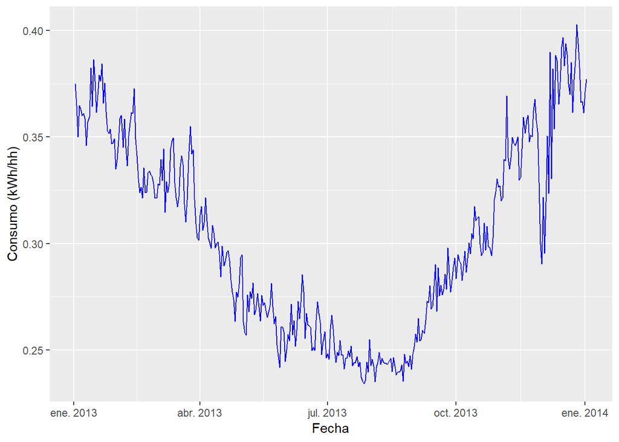

```r
consumo_medio_dia <- aggregate(data["consumo"], by=list(yday(data$fecha)), mean)

p = ggplot() +
  geom_line(data = consumo_medio_dia, aes(x=consumo_medio_dia[,1]+as.Date("2013-01-01"), y=consumo_medio_dia$consumo), color='blue') +
  xlab('Fecha') +
  ylab('Consumo (kWh/hh)')
print(p)
```

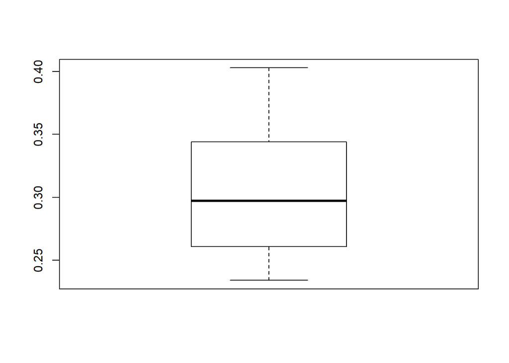

```r
boxplot(consumo_medio_dia$consumo)
```

- Consumo medio diario y temperatura (kWh/hh / day & Temp)

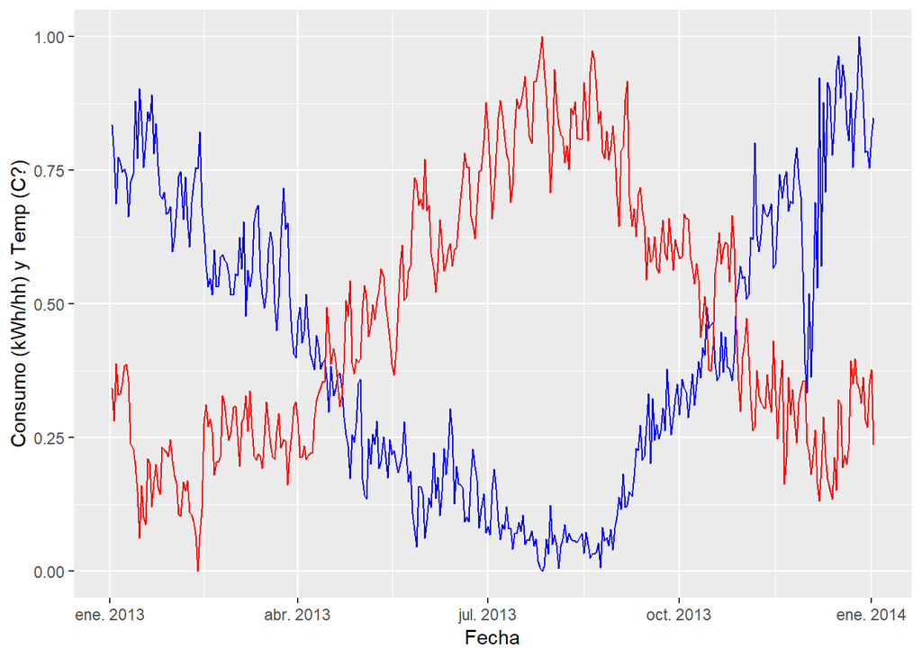

```r
consumo_medio_dia <- aggregate(data["consumo"], by=list(yday(data$fecha)), mean)
temp_media_dia <- aggregate(data["temperature"], by=list(yday(data$fecha)), mean)

normalize <- function(x) {
  return ((x - min(x)) / (max(x) - min(x)))
}

p = ggplot() +
  geom_line(data = consumo_medio_dia, aes(x=consumo_medio_dia[,1]+as.Date("2013-01-01"), y=normalize(consumo_medio_dia$consumo)), color='blue') +
  geom_line(data = consumo_medio_dia, aes(x=temp_media_dia[,1]+as.Date("2013-01-01"), y=normalize(temp_media_dia$temperature)), color='red') +
  xlab('Fecha') +
  ylab('Consumo (kWh/hh) y Temp (C?)')
print(p)
```

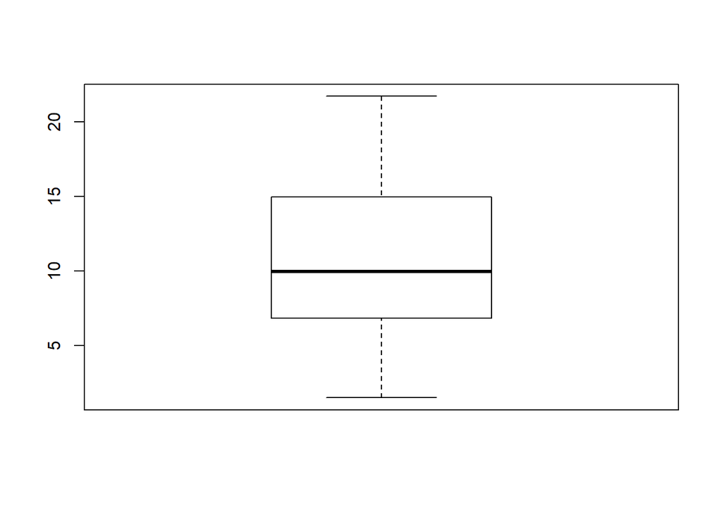

```r
boxplot(temp_media_dia$temperature)
```

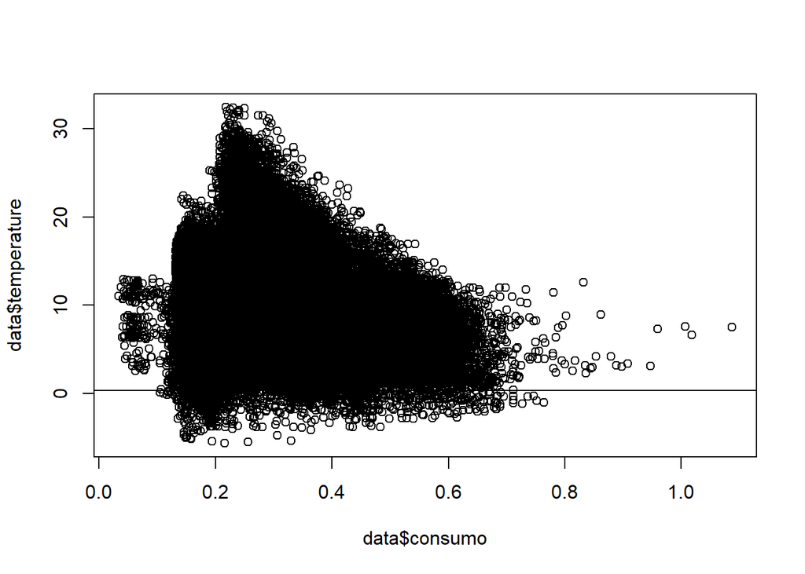

```r
plot(data$consumo, data$temperature)
abline(lm(data$consumo ~data$temperature))
```

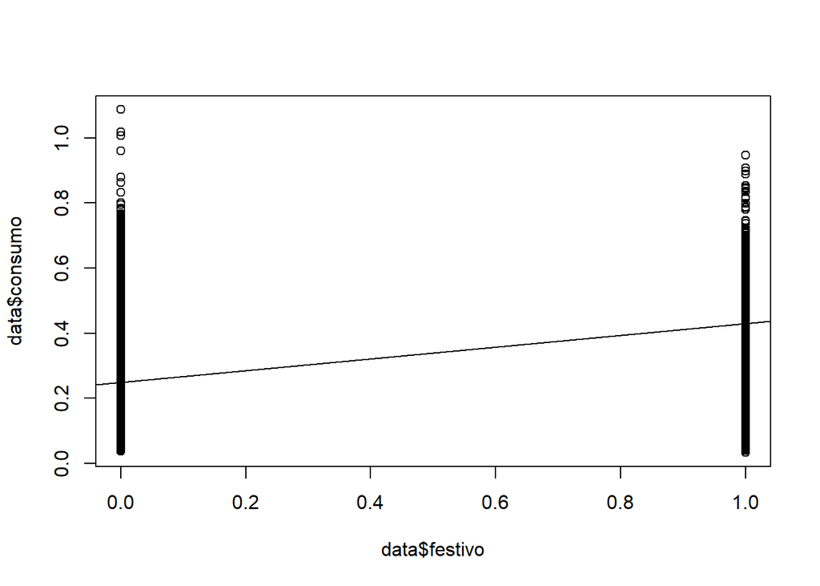

```r
plot(data$festivo, data$consumo)
abline(lm(data$festivo ~ data$consumo))
```

- Correlación entre las variables

```r
data_with_no_dates <- data[,2:length(data)]
correlation_matrix <- round(cor(data_with_no_dates), 1)
correlation_matrix
```

```
##                     consumo festivo visibility windBearing temperature
## consumo                 1.0     0.0        0.0         0.0        -0.2
## festivo                 0.0     1.0        0.1         0.0         0.0
## visibility              0.0     0.1        1.0         0.2         0.2
## windBearing             0.0     0.0        0.2         1.0         0.0
## temperature            -0.2     0.0        0.2         0.0         1.0
## dewPoint               -0.3     0.0        0.0         0.1         0.9
## pressure               -0.1     0.0        0.0         0.0         0.1
## apparentTemperature    -0.2     0.0        0.2         0.1         1.0
## windSpeed               0.1     0.0        0.2         0.1         0.0
## humidity                0.0     0.0       -0.5         0.0        -0.4
##                     dewPoint pressure apparentTemperature windSpeed
## consumo                 -0.3     -0.1                -0.2       0.1
## festivo                  0.0      0.0                 0.0       0.0
## visibility               0.0      0.0                 0.2       0.2
## windBearing              0.1      0.0                 0.1       0.1
## temperature              0.9      0.1                 1.0       0.0
## dewPoint                 1.0     -0.1                 0.9       0.0
## pressure                -0.1      1.0                 0.1      -0.4
## apparentTemperature      0.9      0.1                 1.0       0.0
## windSpeed                0.0     -0.4                 0.0       1.0
## humidity                 0.1     -0.2                -0.4      -0.2
##                     humidity
## consumo                  0.0
## festivo                  0.0
## visibility              -0.5
## windBearing              0.0
## temperature             -0.4
## dewPoint                 0.1
## pressure                -0.2
## apparentTemperature     -0.4
## windSpeed               -0.2
## humidity                 1.0
```

[figure not shown]

```r
ggcorrplot(correlation_matrix, hc.order = TRUE, type = "lower")
```